# Python 資料前處理與EDA

> 第一天

[數聚點](https://www.datainpoint.com) | 郭耀仁 yaojenkuo@datainpoint.com

```python
!wget -O ks2022.py "https://raw.githubusercontent.com/datainpoint/classroom-nccu-dac/main/ks2022.py"
```

## 誰是資料分析師

## 什麼是資料

- 資料是一個定義廣泛的名詞，又稱數據，是通過觀測得到的特徵或資訊。
- 資料存在不同的類別與形式，像是文字、數值、布林或者未定義值；當資料有關於多個人事時地物，就會以資料結構來組織。
- 更精準地說，如果我們希望透過電腦來處理資料，就會面對將觀測所得的特徵或資訊，轉換為不同類別的資料、並儲存於不同形式的資料結構。

## 什麼是分析

- 將某個有興趣的問題拆分為數個小問題。
- 研究小問題與有興趣的問題之間的關係，像是相關或者因果等。

## 什麼是「資料分析」

「資料分析」是一門透過邏輯、事實以及量化作為基準來拆解問題、並尋求解答的方法論。

## 為什麼透過「資料分析」處理問題

資料分析是連接問題與行動計畫之間的橋樑，基於邏輯、事實以及量化的行動計畫，我們才能夠對於問題的解決有樂觀預期。

1. 問題。
2. 資料分析。
3. 行動計畫。
4. 評估。
5. ...重複循環。

## 不同導向的分析

- **資料導向的分析**。
- 商業導向的分析。
- 報酬導向的分析。
- 財報導向的分析。
- 交易導向的分析。
- ...等。

## 不同導向、不同專注，沒有必要文人相輕

- 資料導向專注在資訊價值。
- 商業導向專注在推論邏輯。
- 報酬導向專注在損益計算。
- 財報導向專注在公司財務的基本面。
- 交易導向專注在公司股價的技術面。
- ...等。

## 資料導向的分析流程

[figure not shown]

來源：https://r4ds.had.co.nz/introduction.html

## 誰是「資料分析師」

透過邏輯、事實以及量化作為基準、透過程式來處理並分析資料，進而拆解問題、並尋求解答的專業人士，很有可能是一位「擅長寫程式的分析師」、也可能是一位「擅長分析的程式設計師」。

## Kaggle 機器學習與資料科學調查

## 什麼是 Kaggle

> Kaggle 是一個機器學習與資料分析競賽平台，企業會在 Kaggle 發佈競賽資料供資料科學家訓練、建立模型並與其他的參賽者比較模型的準確度。於 2017 年被 Google 收購。

來源：https://en.wikipedia.org/wiki/Kaggle

## 關於 Kaggle 機器學習與資料科學調查

- 從 2017 年起寄送電子問卷給網站會員填寫。
- 至今年（2022 年）已經連續六屆都有舉辦調查與資料分析競賽。
- 今年（2022 年）有效填寫人數有 23,997 位會員。

來源：https://www.kaggle.com/c/kaggle-survey-2022

## 透過 Kaggle 機器學習與資料科學調查探索資料分析師日常的工作內容與使用工具

- 主要工作內容。
- 程式語言。
- 整合開發環境、純文字編輯器。
- 視覺化模組、套件。
- 商業智能軟體。
- 機器學習模組、套件。
- 關聯式資料庫管理系統。

## 探索資料分析師的主要工作內容

> Q28: Select any activities that make up an important part of your role at work: (Select all that apply)

## 資料分析師的主要工作內容

- 分析與暸解資料進而影響產品或商業上的決策。
- 建構維運資料底層架構協助業務使用者分析資料。
- 對新的業務領域應用機器學習的模型。

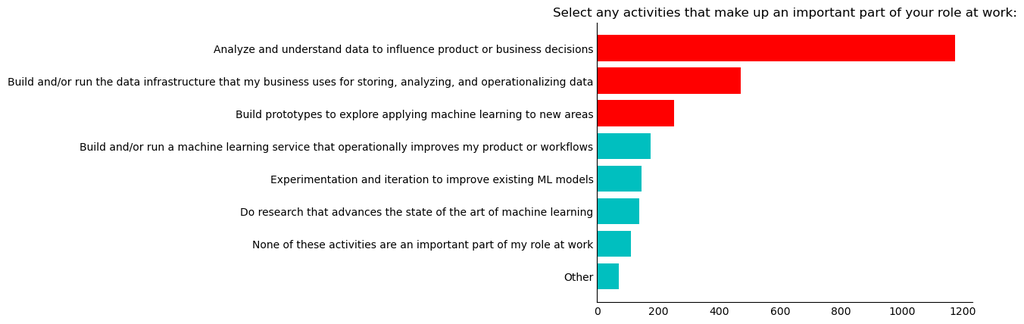

```python
kaggle_survey.plot_survey_summary("Q28")
```

## 探索資料分析師使用的程式語言

> Q12: What programming languages do you use on a regular basis? (Select all that apply)

## 資料分析師主要使用的程式語言是 Python、SQL 與 R

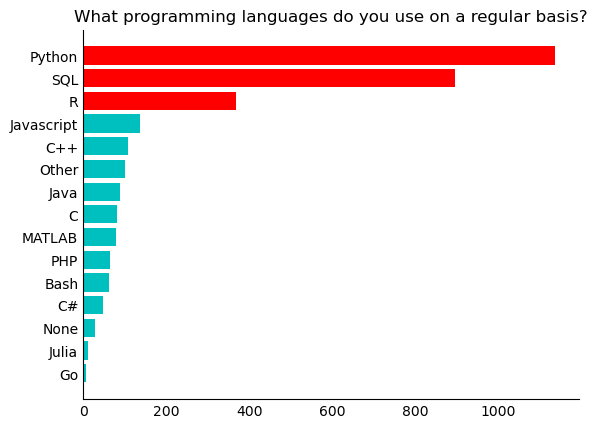

```python
kaggle_survey.plot_survey_summary("Q12")
```

## 探索資料分析師使用的整合開發環境、純文字編輯器

> Q13: Which of the following integrated development environments (IDE's) do you use on a regular basis? (Select all that apply)

## 資料分析師以 Jupyter Notebook、Visual Studio Code、PyCharm 與 JupyterLab 撰寫 Python、以 RStudio 撰寫 R

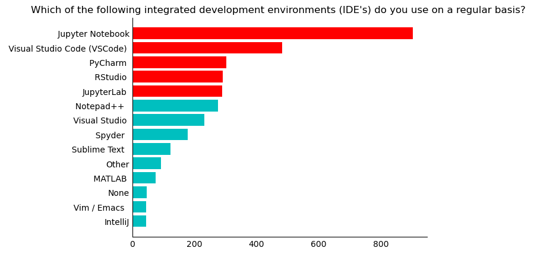

```python
kaggle_survey.plot_survey_summary("Q13", n=5)
```

## 探索資料分析師使用的視覺化模組、套件

> Q15: Do you use any of the following data visualization libraries on a regular basis? (Select all that apply)

## 資料分析師在 Python 使用 matplotlib、seaborn 與 plotly，在 R 使用 ggplot2 與 plotly

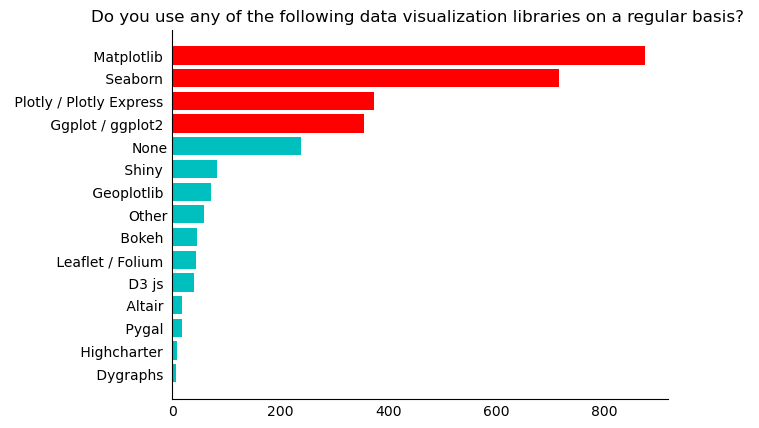

```python
kaggle_survey.plot_survey_summary("Q15", n=4)
```

## 探索資料分析師使用的商業智能軟體

> Q36: Do you use any of the following business intelligence tools? (Select all that apply)

## 資料分析師主要使用的商業智能軟體是 Tableau 與 Microsoft Power BI

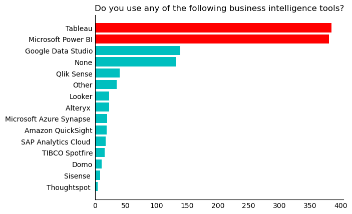

```python
kaggle_survey.plot_survey_summary("Q36", n=2)
```

## 探索資料分析師使用的機器學習模組、套件

> Q17: Which of the following machine learning frameworks do you use on a regular basis? (Select all that apply)

## 資料分析師主要使用的機器學習模組是 Scikit-learn、Xgboost、深度學習模組是 TensorFlow、Keras、PyTorch

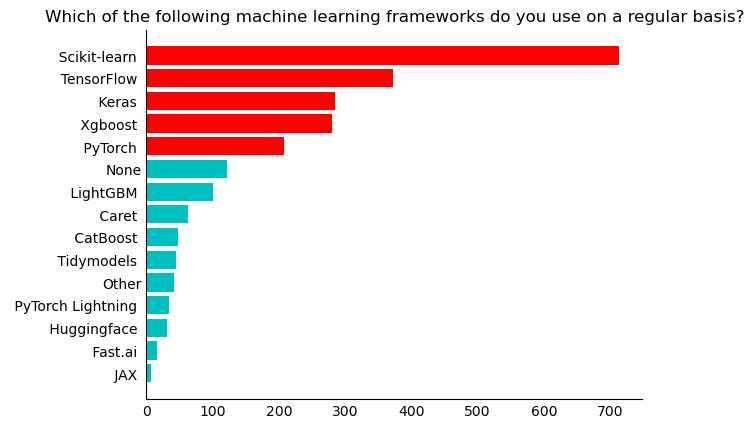

```python
kaggle_survey.plot_survey_summary("Q17", n=5)
```

## 探索資料分析師使用的關聯式資料庫管理系統

> Q35: Do you use any of the following data products (relational databases, data warehouses, data lakes, or similar)? (Select all that apply)

## 資料分析師主要使用的關聯式資料庫管理系統為 MySQL、Microsoft SQL Server 與 PostgreSQL

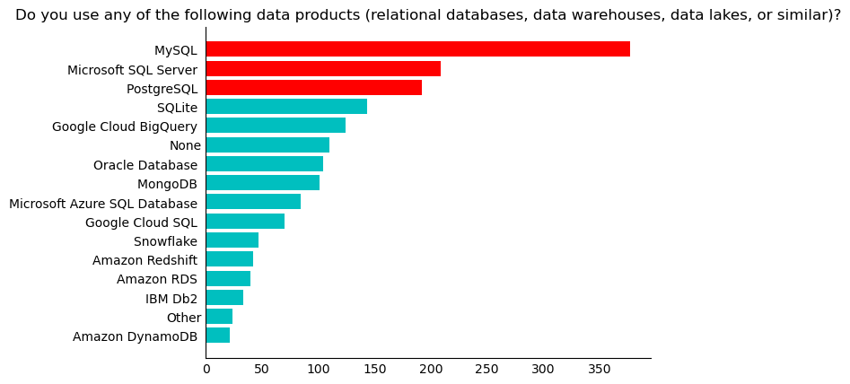

```python
kaggle_survey.plot_survey_summary("Q35", n=3)
```

## 關於 Pandas

## 什麼是 Pandas

> Pandas 是 Python 處理表格式資料（Tabular data）的第三方模組，它創造了 `Index`、`Series` 與 `DataFrame` 的資料結構類別，讓 Python 在面對表格式資料時能夠用更直覺的觀念操作。

來源：https://github.com/pandas-dev/pandas

## （沒什麼用的冷知識）Pandas 跟熊貓「沒有關係」

1. **Pan**el(自從版本 0.20.0 之後棄用)
2. **Da**taFrame
3. **S**eries

[figure not shown]

來源：https://media.giphy.com/media/46Zj6ze2Z2t4k/giphy.gif

## 根據說明文件的範例載入

來源：https://pandas.pydata.org/docs/user_guide/10min.html

```python
import pandas as pd
```

## 如果環境中沒有安裝 Pandas，載入時會遭遇 `ModuleNotFoundError`

```
Traceback (most recent call last):
  File "<stdin>", line 1, in <module>
ModuleNotFoundError: No module named 'pandas'
```

## 如果遭遇 `ModuleNotFoundError` 可以在終端機使用 `pip install pandas` 或者 `conda install pandas` 指令安裝

若要指定模組版本可以加上 `==MAJOR.MINOR.PATCH`

```
pip install pandas
```

或者

```
conda install pandas
```

## 可以透過兩個屬性檢查版本號與安裝路徑

- `__version__` 屬性檢查版本號。
- `__file__` 屬性檢查安裝路徑。

```python
print(pd.__version__)
print(pd.__file__)
```

```
1.4.4
/Users/kuoyaojen/opt/miniconda3/lib/python3.9/site-packages/pandas/__init__.py
```

## 入門 Pandas 的第一步就是掌握 `Index`、`ndarray`、`Series` 與 `DataFrame` 四個資料結構類別彼此之間的關係

- `Series` 由 `Index` 與 `ndarray` 組合而成。
- `DataFrame` 由數個共享同一個 `Index` 的 `Series` 組合而成。

## 具備 `tuple` 與 `set` 特性的 `Index`

## Pandas 的 `Index` 類別

使用 `pd.Index()` 函數創造 `Index` 類別的實例。

```python
import numpy as np
```

```python
primes_array = np.array([2, 3, 5, 7, 11, 13, 17, 19, 23, 29])
prime_indexes = pd.Index(primes_array)
print(prime_indexes)
print(type(prime_indexes))
```

```
Int64Index([2, 3, 5, 7, 11, 13, 17, 19, 23, 29], dtype='int64')
<class 'pandas.core.indexes.numeric.Int64Index'>
```

## `Index` 的基礎屬性

- `Index.dtype` 資料類別。
- `Index.size` 元素個數。

```python
print(prime_indexes.dtype)
print(prime_indexes.size)
```

```
int64
10
```

## `Index` 類別結合 Python 內建的 `tuple` 與 `set` 兩種資料結構類別的特性

- 具有 `tuple` 無法更動的特性。
- 具有 `set` 集合運算的特性。

## `Index` 類別具有 `tuple` 無法更動的特性

```python
# Index has the characteristics of a tuple
primes_array = np.array([2, 3, 5, 7, 11, 13, 17, 19, 23, 29])
prime_indexes = pd.Index(primes_array)
try:
    prime_indexes[-1] = 31
except TypeError as error_message:
    print(error_message)
```

```
Index does not support mutable operations
```

## `Index` 類別具有 `set` 集合運算的特性

```python
# Index has the characteristics of a set
primes_array = np.array([2, 3, 5, 7, 11, 13, 17, 19, 23, 29])
prime_indexes = pd.Index(primes_array)
odd_indexes = pd.Index(np.arange(1, 30, 2))
print(prime_indexes)
print(odd_indexes)
```

```
Int64Index([2, 3, 5, 7, 11, 13, 17, 19, 23, 29], dtype='int64')
Int64Index([1, 3, 5, 7, 9, 11, 13, 15, 17, 19, 21, 23, 25, 27, 29], dtype='int64')
```

## `Index` 具有與 `set` 同樣名稱的集合運算方法

- `Index.intersection()` 交集。
- `Index.union()` 聯集。
- `Index.difference()` 差集。
- `Index.symmetric_difference()` 對稱差集。

```python
# Set operations of Index
print(prime_indexes.intersection(odd_indexes))
print(prime_indexes.union(odd_indexes))
print(prime_indexes.difference(odd_indexes))
print(odd_indexes.difference(prime_indexes))
print(prime_indexes.symmetric_difference(odd_indexes))
```

```
Int64Index([3, 5, 7, 11, 13, 17, 19, 23, 29], dtype='int64')
Int64Index([1, 2, 3, 5, 7, 9, 11, 13, 15, 17, 19, 21, 23, 25, 27, 29], dtype='int64')
Int64Index([2], dtype='int64')
Int64Index([1, 9, 15, 21, 25, 27], dtype='int64')
Int64Index([1, 2, 9, 15, 21, 25, 27], dtype='int64')
```

## `Index` 加 `ndarray` 等於 `Series`

## Pandas 的 `Series` 類別

使用 `pd.Series()` 函數創造 `Series` 類別的實例。

```python
months_array = np.arange(1, 13)
months_series = pd.Series(months_array)
print(months_series)
print(type(months_series))
```

```
0      1
1      2
2      3
3      4
4      5
5      6
6      7
7      8
8      9
9     10
10    11
11    12
dtype: int64
<class 'pandas.core.series.Series'>
```

## `Series` 的基礎屬性與方法

- `Series.dtype` 資料類別。
- `Series.size` 元素個數。
- `Series.index` 取出 `Series` 的 `Index` 部分。
- `Series.values` 取出 `Series` 的 `ndarray` 部分。
- `Series.astype()` 轉換 `Series` 的資料類別。

```python
print(months_series.dtype)
print(months_series.size)
```

```
int64
12
```

## `Series` 由 `Index` 與 `ndarray` 組合而成

```python
print(months_series.index)
print(type(months_series.index))
```

```
RangeIndex(start=0, stop=12, step=1)
<class 'pandas.core.indexes.range.RangeIndex'>
```

```python
print(months_series.values)
print(type(months_series.values))
```

```
[ 1  2  3  4  5  6  7  8  9 10 11 12]
<class 'numpy.ndarray'>
```

## 調整 `Series` 的 `Index`

- 在建立的時候指定。
- 透過 `Series.index` 更新。

## 在建立的時候指定

```python
months_abbreviation = ["JAN", "FEB", "MAR", "APR", "MAY", "JUN", "JUL", "AUG", "SEP", "OCT", "NOV", "DEC"]
months_series = pd.Series(months_array, index=months_abbreviation)
months_series
```

```
JAN     1
FEB     2
MAR     3
APR     4
MAY     5
JUN     6
JUL     7
AUG     8
SEP     9
OCT    10
NOV    11
DEC    12
dtype: int64
```

## 透過 `Series.index` 更新

```python
months_abbreviation = ["JAN", "FEB", "MAR", "APR", "MAY", "JUN", "JUL", "AUG", "SEP", "OCT", "NOV", "DEC"]
months_series = pd.Series(months_array)
months_series.index = months_abbreviation
months_series
```

```
JAN     1
FEB     2
MAR     3
APR     4
MAY     5
JUN     6
JUL     7
AUG     8
SEP     9
OCT    10
NOV    11
DEC    12
dtype: int64
```

## 如何取出 `Series` 中的元素

- 以元素位置 indexing/slicing
- 以 `Index` indexing/slicing

## 以元素位置 indexing/slicing

```python
print(months_series[0])
print(months_series[:3])
```

```
1
JAN    1
FEB    2
MAR    3
dtype: int64
```

## 以 `Index` indexing/slicing

```python
print(months_series["JAN"])
print(months_series["JAN":"MAR"])
```

```
1
JAN    1
FEB    2
MAR    3
dtype: int64
```

## 轉換 `Series` 的資料類別

- 在建立的時候指定。
- 透過 `Series.astype()` 轉換 `Series` 的資料類別。

## 在建立的時候指定

```python
months_series = pd.Series(months_array, dtype=float)
months_series
```

```
0      1.0
1      2.0
2      3.0
3      4.0
4      5.0
5      6.0
6      7.0
7      8.0
8      9.0
9     10.0
10    11.0
11    12.0
dtype: float64
```

## `Series.astype()` 轉換 `Series` 的資料類別

```python
months_series = pd.Series(months_array)
print(months_series.dtype)
print(months_series.astype(float))
```

```
int64
0      1.0
1      2.0
2      3.0
3      4.0
4      5.0
5      6.0
6      7.0
7      8.0
8      9.0
9     10.0
10    11.0
11    12.0
dtype: float64
```

## 結合多個相同 `Index` 的 `Series` 成為 `DataFrame`

## Pandas 的 `DataFrame` 類別

使用 `pd.DataFrame()` 函數創造 `DataFrame` 類別的實例。

- 輸入以欄為基準（Column-based）的資料內容。
- 輸入以列為基準（Row-based）的資料內容。

## 輸入以欄為基準（Column-based）的資料內容

```python
movie_df = pd.DataFrame()
movie_df["title"] = ["The Shawshank Redemption", "The Dark Knight", "Schindler's List", "Forrest Gump", "Inception"]
movie_df["imdb_rating"] = [9.3, 9.0, 8.9, 8.8, 8.7]
movie_df["release_year"] = [1994, 2008, 1993, 1994, 2010]
print(movie_df)
print(type(movie_df))
```

```
                      title  imdb_rating  release_year
0  The Shawshank Redemption          9.3          1994
1           The Dark Knight          9.0          2008
2          Schindler's List          8.9          1993
3              Forrest Gump          8.8          1994
4                 Inception          8.7          2010
<class 'pandas.core.frame.DataFrame'>
```

## 輸入以列為基準（Row-based）的資料內容

```python
movies = [
    {"title": "The Shawshank Redemption", "imdb_rating": 9.3, "release_year": 1994},
    {"title": "The Dark Knight", "imdb_rating": 9.0, "release_year": 2008},
    {"title": "Schindler's List", "imdb_rating": 8.9, "release_year": 1993},
    {"title": "Forrest Gump", "imdb_rating": 8.8, "release_year": 1994},
    {"title": "Inception", "imdb_rating": 8.7, "release_year": 2010},
]
movie_df = pd.DataFrame(movies)
print(movie_df)
print(type(movie_df))
```

```
                      title  imdb_rating  release_year
0  The Shawshank Redemption          9.3          1994
1           The Dark Knight          9.0          2008
2          Schindler's List          8.9          1993
3              Forrest Gump          8.8          1994
4                 Inception          8.7          2010
<class 'pandas.core.frame.DataFrame'>
```

## Jupyter Notebook 針對 `DataFrame` 類別有特別的顯示外觀

```python
movie_df
```

|  | title | imdb_rating | release_year |
| --- | --- | --- | --- |
| 0 | The Shawshank Redemption | 9.3 | 1994 |
| 1 | The Dark Knight | 9.0 | 2008 |
| 2 | Schindler's List | 8.9 | 1993 |
| 3 | Forrest Gump | 8.8 | 1994 |
| 4 | Inception | 8.7 | 2010 |

## `DataFrame` 的基礎屬性

- `DataFrame.dtypes` 資料類別。
- `DataFrame.shape` 外型。
- `DataFrame.index` 取出列標籤（row labels）部分。
- `DataFrame.columns` 取出欄標籤（column labels）的部分。

```python
print(movie_df.dtypes)
print(movie_df.shape)
print(movie_df.index)
print(movie_df.columns)
```

```
title            object
imdb_rating     float64
release_year      int64
dtype: object
(5, 3)
RangeIndex(start=0, stop=5, step=1)
Index(['title', 'imdb_rating', 'release_year'], dtype='object')
```

## `DataFrame` 由數個 `Series` 共享同一個 `Index` 組成

```python
print(type(movie_df.index))
print(type(movie_df["title"]))
print(type(movie_df["imdb_rating"]))
print(type(movie_df["release_year"]))
```

```
<class 'pandas.core.indexes.range.RangeIndex'>
<class 'pandas.core.series.Series'>
<class 'pandas.core.series.Series'>
<class 'pandas.core.series.Series'>
```

## `DataFrame` 的基礎方法

- `DataFrame.head(n)` 檢視前 `n` 列。
- `DataFrame.tail(n)` 檢視後 `n` 列。
- `DataFrame.describe()` 檢視數值欄位的描述性統計。
- `DataFrame.info()` 檢視詳細資訊。

## 檢視前 `n` 列、後 `n` 列

- `DataFrame.head(n)` 檢視前 `n` 列。
- `DataFrame.tail(n)` 檢視後 `n` 列。

```python
movie_df.head(3)
```

|  | title | imdb_rating | release_year |
| --- | --- | --- | --- |
| 0 | The Shawshank Redemption | 9.3 | 1994 |
| 1 | The Dark Knight | 9.0 | 2008 |
| 2 | Schindler's List | 8.9 | 1993 |

```python
movie_df.tail(2)
```

|  | title | imdb_rating | release_year |
| --- | --- | --- | --- |
| 3 | Forrest Gump | 8.8 | 1994 |
| 4 | Inception | 8.7 | 2010 |

## `DataFrame.describe()` 檢視數值欄位的描述性統計

```python
movie_df.describe()
```

|  | imdb_rating | release_year |
| --- | --- | --- |
| count | 5.000000 | 5.000000 |
| mean | 8.940000 | 1999.800000 |
| std | 0.230217 | 8.438009 |
| min | 8.700000 | 1993.000000 |
| 25% | 8.800000 | 1994.000000 |
| 50% | 8.900000 | 1994.000000 |
| 75% | 9.000000 | 2008.000000 |
| max | 9.300000 | 2010.000000 |

## `DataFrame.info()` 檢視詳細資訊

```python
movie_df.info()
```

```
<class 'pandas.core.frame.DataFrame'>
RangeIndex: 5 entries, 0 to 4
Data columns (total 3 columns):
 #   Column        Non-Null Count  Dtype
---  ------        --------------  -----
 0   title         5 non-null      object
 1   imdb_rating   5 non-null      float64
 2   release_year  5 non-null      int64
dtypes: float64(1), int64(1), object(1)
memory usage: 248.0+ bytes
```

## 實作練習

## 載入 `kaggle_survey_2022_responses.csv`：`pd.read_csv()`

```python
file_url = "https://raw.githubusercontent.com/datainpoint/classroom-nccu-dac/main/kaggle_survey_2022_responses.csv"
kaggle_survey_2022 = pd.___(___, skiprows=[1], low_memory=False)
```

```python
file_url = "https://raw.githubusercontent.com/datainpoint/classroom-nccu-dac/main/kaggle_survey_2022_responses.csv"
kaggle_survey_2022 = pd.read_csv(file_url, skiprows=[1], low_memory=False)
```

## 檢視物件的類別：`type()`

```python
___(kaggle_survey_2022)
```

```
pandas.core.frame.DataFrame
```

```python
type(kaggle_survey_2022)
```

```
pandas.core.frame.DataFrame
```

## 檢視資料框的外型：`df.shape`

```python
kaggle_survey_2022.___
```

```
(23997, 296)
```

```python
kaggle_survey_2022.shape
```

```
(23997, 296)
```

## 檢視資料框的前五列：`df.head()`

```python
kaggle_survey_2022.___()
```

|  | Duration (in seconds) | Q2 | Q3 | Q4 | Q5 | Q6_1 | Q6_2 | Q6_3 | Q6_4 | Q6_5 | ... | Q44_3 | Q44_4 | Q44_5 | Q44_6 | Q44_7 | Q44_8 | Q44_9 | Q44_10 | Q44_11 | Q44_12 |
| --- | --- | --- | --- | --- | --- | --- | --- | --- | --- | --- | --- | --- | --- | --- | --- | --- | --- | --- | --- | --- | --- |
| 0 | 121 | 30-34 | Man | India | No | NaN | NaN | NaN | NaN | NaN | ... | NaN | NaN | NaN | NaN | NaN | NaN | NaN | NaN | NaN | NaN |
| 1 | 462 | 30-34 | Man | Algeria | No | NaN | NaN | NaN | NaN | NaN | ... | NaN | NaN | NaN | NaN | NaN | NaN | NaN | NaN | NaN | NaN |
| 2 | 293 | 18-21 | Man | Egypt | Yes | Coursera | edX | NaN | DataCamp | NaN | ... | NaN | Kaggle (notebooks, forums, etc) | NaN | YouTube (Kaggle YouTube, Cloud AI Adventures, ... | Podcasts (Chai Time Data Science, O’Reilly Dat... | NaN | NaN | NaN | NaN | NaN |
| 3 | 851 | 55-59 | Man | France | No | Coursera | NaN | Kaggle Learn Courses | NaN | NaN | ... | NaN | Kaggle (notebooks, forums, etc) | Course Forums (forums.fast.ai, Coursera forums... | NaN | NaN | Blogs (Towards Data Science, Analytics Vidhya,... | NaN | NaN | NaN | NaN |
| 4 | 232 | 45-49 | Man | India | Yes | NaN | NaN | NaN | NaN | NaN | ... | NaN | NaN | NaN | NaN | NaN | Blogs (Towards Data Science, Analytics Vidhya,... | NaN | NaN | NaN | NaN |

5 rows × 296 columns

```python
kaggle_survey_2022.head()
```

|  | Duration (in seconds) | Q2 | Q3 | Q4 | Q5 | Q6_1 | Q6_2 | Q6_3 | Q6_4 | Q6_5 | ... | Q44_3 | Q44_4 | Q44_5 | Q44_6 | Q44_7 | Q44_8 | Q44_9 | Q44_10 | Q44_11 | Q44_12 |
| --- | --- | --- | --- | --- | --- | --- | --- | --- | --- | --- | --- | --- | --- | --- | --- | --- | --- | --- | --- | --- | --- |
| 0 | 121 | 30-34 | Man | India | No | NaN | NaN | NaN | NaN | NaN | ... | NaN | NaN | NaN | NaN | NaN | NaN | NaN | NaN | NaN | NaN |
| 1 | 462 | 30-34 | Man | Algeria | No | NaN | NaN | NaN | NaN | NaN | ... | NaN | NaN | NaN | NaN | NaN | NaN | NaN | NaN | NaN | NaN |
| 2 | 293 | 18-21 | Man | Egypt | Yes | Coursera | edX | NaN | DataCamp | NaN | ... | NaN | Kaggle (notebooks, forums, etc) | NaN | YouTube (Kaggle YouTube, Cloud AI Adventures, ... | Podcasts (Chai Time Data Science, O’Reilly Dat... | NaN | NaN | NaN | NaN | NaN |
| 3 | 851 | 55-59 | Man | France | No | Coursera | NaN | Kaggle Learn Courses | NaN | NaN | ... | NaN | Kaggle (notebooks, forums, etc) | Course Forums (forums.fast.ai, Coursera forums... | NaN | NaN | Blogs (Towards Data Science, Analytics Vidhya,... | NaN | NaN | NaN | NaN |
| 4 | 232 | 45-49 | Man | India | Yes | NaN | NaN | NaN | NaN | NaN | ... | NaN | NaN | NaN | NaN | NaN | Blogs (Towards Data Science, Analytics Vidhya,... | NaN | NaN | NaN | NaN |

5 rows × 296 columns

## 刪除資料框的欄位：`df.drop()`

```python
kaggle_survey_2022 = kaggle_survey_2022.___("Duration (in seconds)", axis=1)
```

```python
kaggle_survey_2022 = kaggle_survey_2022.drop("Duration (in seconds)", axis=1)
```

## 檢視資料框的欄位名稱：`df.columns`

```python
"Duration (in seconds)" in kaggle_survey_2022.___
```

```
False
```

```python
"Duration (in seconds)" in kaggle_survey_2022.columns
```

```
False
```

## 填答者數量：`df.shape[0]`

```python
kaggle_survey_2022.___[0]
```

```
23997
```

```python
kaggle_survey_2022.shape[0]
```

```
23997
```

## 單選題摘要分析：`df["column"].value_counts()`

```python
kaggle_survey_2022[___].___()
```

```
Data Scientist                                                      1929
Data Analyst (Business, Marketing, Financial, Quantitative, etc)    1538
Currently not employed                                              1432
Software Engineer                                                    980
Teacher / professor                                                  833
Manager (Program, Project, Operations, Executive-level, etc)         832
Other                                                                754
Research Scientist                                                   593
Machine Learning/ MLops Engineer                                     571
Engineer (non-software)                                              465
Data Engineer                                                        352
Statistician                                                         125
Data Architect                                                        95
Data Administrator                                                    70
Developer Advocate                                                    61
Name: Q23, dtype: int64
```

```python
kaggle_survey_2022["Q23"].value_counts()
```

```
Data Scientist                                                      1929
Data Analyst (Business, Marketing, Financial, Quantitative, etc)    1538
Currently not employed                                              1432
Software Engineer                                                    980
Teacher / professor                                                  833
Manager (Program, Project, Operations, Executive-level, etc)         832
Other                                                                754
Research Scientist                                                   593
Machine Learning/ MLops Engineer                                     571
Engineer (non-software)                                              465
Data Engineer                                                        352
Statistician                                                         125
Data Architect                                                        95
Data Administrator                                                    70
Developer Advocate                                                    61
Name: Q23, dtype: int64
```

```python
kaggle_survey_2022[___].___()
```

```
Computers/Technology                      2321
Academics/Education                       1447
Accounting/Finance                         802
Other                                      750
Manufacturing/Fabrication                  561
Medical/Pharmaceutical                     509
Government/Public Service                  500
Online Service/Internet-based Services     461
Retail/Sales                               398
Energy/Mining                              320
Insurance/Risk Assessment                  256
Marketing/CRM                              246
Non-profit/Service                         194
Broadcasting/Communications                179
Shipping/Transportation                    150
Name: Q24, dtype: int64
```

```python
kaggle_survey_2022["Q24"].value_counts()
```

```
Computers/Technology                      2321
Academics/Education                       1447
Accounting/Finance                         802
Other                                      750
Manufacturing/Fabrication                  561
Medical/Pharmaceutical                     509
Government/Public Service                  500
Online Service/Internet-based Services     461
Retail/Sales                               398
Energy/Mining                              320
Insurance/Risk Assessment                  256
Marketing/CRM                              246
Non-profit/Service                         194
Broadcasting/Communications                179
Shipping/Transportation                    150
Name: Q24, dtype: int64
```